# Linear Regression to Predict Weekly Sales

Syed Muhammed Abubaker Tien Ho Bradley Haren Jacob Haussler

```r
library(dplyr)
```

# Import the dataset

```r
walmart <- read.csv('./Walmart_Store_sales.csv', header = TRUE)
head(walmart)
```

```
##   Store       Date Weekly_Sales Holiday_Flag Temperature Fuel_Price      CPI
## 1     1   5/2/2010      1643691            0       42.31      2.572 211.0964
## 2     1  12/2/2010      1641957            1       38.51      2.548 211.2422
## 3     1 19-02-2010      1611968            0       39.93      2.514 211.2891
## 4     1 26-02-2010      1409728            0       46.63      2.561 211.3196
## 5     1   5/3/2010      1554807            0       46.50      2.625 211.3501
## 6     1  12/3/2010      1439542            0       57.79      2.667 211.3806
##   Unemployment
## 1        8.106
## 2        8.106
## 3        8.106
## 4        8.106
## 5        8.106
## 6        8.106
```

Let’s look at a pairs plot of the data.

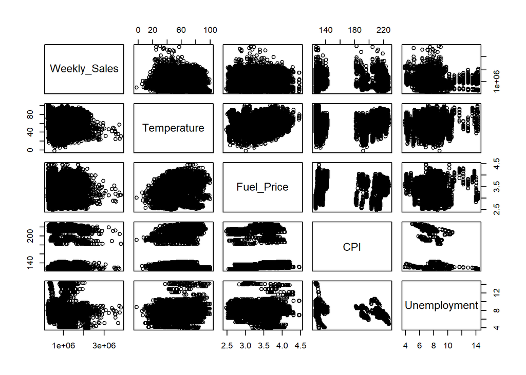

```r
pairs(walmart[c(3,5,6,7,8)])
```

There’s definitely too much data contained here. Since this dataframe contains many different stores, let’s look at one store at a time.

#This probably shouldn’t be included in the final

```r
#here im making a function to find which store would give our model the best r^2 to work with.
#stores 36, 44 have some pretty high adjusted R^2

get_high_r2 = function(df) {
  number_of_stores = 45
  all_values = c()

  for (i in 1:number_of_stores) {
    single_store = df %>% filter(Store == i) %>% arrange(Date)
    mlr = lm(Weekly_Sales ~ factor(Holiday_Flag) + Temperature + Fuel_Price + CPI + Unemployment, data=single_store)
    all_values = c(all_values, summary(mlr)$adj.r.squared)
  }

  return(all_values)
}

which.max(get_high_r2(walmart))
```

```
## [1] 36
```

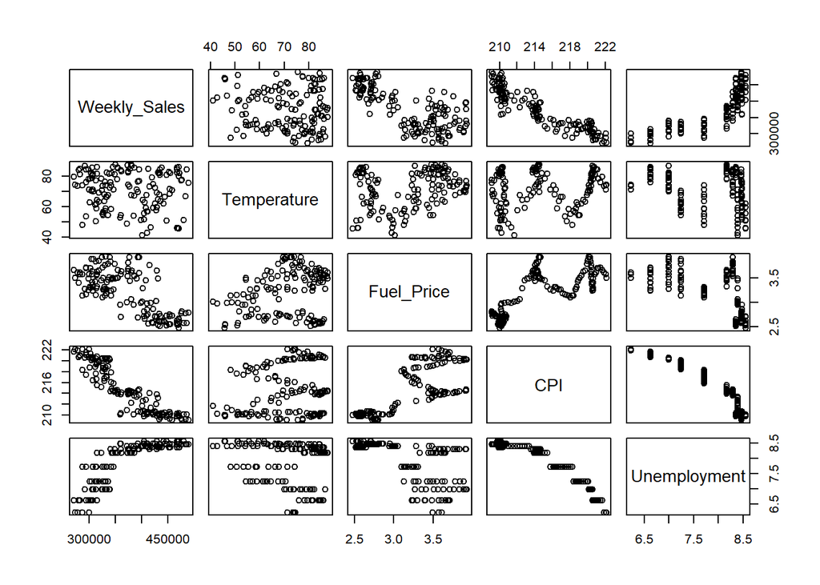

```r
s1 = walmart %>% filter(Store == 36) %>% arrange(Date)
pairs(s1[c(3,5,6,7,8)])
```

This looks much easier to work with. Let’s create a quick model of the data.

```r
mlr = lm(Weekly_Sales ~ factor(Holiday_Flag) + Temperature + Fuel_Price + CPI + Unemployment, data=s1)
summary(mlr)
```

```
##
## Call:
## lm(formula = Weekly_Sales ~ factor(Holiday_Flag) + Temperature +
##     Fuel_Price + CPI + Unemployment, data = s1)
##
## Residuals:
##    Min     1Q Median     3Q    Max
## -67932 -17788   1502  15765  50464
##
## Coefficients:
##                        Estimate Std. Error t value Pr(>|t|)
## (Intercept)           4295736.1   589292.6   7.290 2.24e-11 ***
## factor(Holiday_Flag)1   -9053.8     7998.6  -1.132   0.2596
## Temperature               242.8      179.0   1.356   0.1773
## Fuel_Price               1733.3     9406.9   0.184   0.8541
## CPI                    -17367.1     2418.6  -7.181 4.01e-11 ***
## Unemployment           -27347.8    11913.7  -2.295   0.0232 *
## ---
## Signif. codes:  0 '***' 0.001 '**' 0.01 '*' 0.05 '.' 0.1 ' ' 1
##
## Residual standard error: 23730 on 137 degrees of freedom
## Multiple R-squared:  0.8527, Adjusted R-squared:  0.8473
## F-statistic: 158.6 on 5 and 137 DF,  p-value: < 2.2e-16
```

This actually looks relatively good off the bat, with an adjusted R-squared value of 0.8473. The fitted regression line here is: WeeklySales_hat = 4295736.1 - 9053.8(Holiday_Flag) + 242.8(Temperature) + 1733.3(Fuel_Price) - 17367.1(CPI) - 27347.8(Unemployment)

However, in the pairs plot above we noticed that some of the relationships with weekly sales are not quite linear. Let’s try a log transformation.

```r
mlr_log = lm(log(Weekly_Sales) ~ factor(Holiday_Flag) + Temperature + Fuel_Price + CPI + Unemployment, data=s1)
summary(mlr_log)
```

```
##
## Call:
## lm(formula = log(Weekly_Sales) ~ factor(Holiday_Flag) + Temperature +
##     Fuel_Price + CPI + Unemployment, data = s1)
##
## Residuals:
##       Min        1Q    Median        3Q       Max
## -0.169243 -0.041260  0.002739  0.041219  0.125052
##
## Coefficients:
##                         Estimate Std. Error t value Pr(>|t|)
## (Intercept)           22.6896722  1.5212954  14.915  < 2e-16 ***
## factor(Holiday_Flag)1 -0.0235910  0.0206488  -1.142   0.2552
## Temperature            0.0005696  0.0004621   1.233   0.2199
## Fuel_Price             0.0156304  0.0242845   0.644   0.5209
## CPI                   -0.0444870  0.0062439  -7.125 5.39e-11 ***
## Unemployment          -0.0519033  0.0307560  -1.688   0.0938 .
## ---
## Signif. codes:  0 '***' 0.001 '**' 0.01 '*' 0.05 '.' 0.1 ' ' 1
##
## Residual standard error: 0.06126 on 137 degrees of freedom
## Multiple R-squared:  0.8637, Adjusted R-squared:  0.8587
## F-statistic: 173.6 on 5 and 137 DF,  p-value: < 2.2e-16
```

This actually slightly improved the adjusted R^2 value to 0.8587. This looks like a good change in this case. The new fitted regression line is: log(WeeklySales_hat) = 22.6896722 - 0.0235910(Holiday_Flag) + 0.0005696(Temperature) + 0.0156304(Fuel_Price) - 0.0444870(CPI) - 0.0519033(Unemployment)

We notice that not all of the variable are statistically significant. Let’s try stepwise methods for variable selection in this model and see how it affects the results.

```r
library(StepReg)
library(car)
stepwise(s1[c(3,4,5,6,7,8)], y="Weekly_Sales", selection = "bidirection", select = "adjRsq")
```

```
## $process
##   Step EffectEntered EffectRemoved EffectNumber    Select
## 1    0     intercept                          1 0.0000000
## 2    1           CPI                          2 0.8362462
## 3    2  Unemployment                          3 0.8457792
## 4    3   Temperature                          4 0.8479986
## 5    4  Holiday_Flag                          5 0.8483760
##
## $variate
## [1] "intercept"    "CPI"          "Unemployment" "Temperature"  "Holiday_Flag"
```

```r
mlr_step <- lm(log(Weekly_Sales) ~ CPI + Unemployment + Temperature + factor(Holiday_Flag), data = s1)
summary(mlr_step)
```

```
##
## Call:
## lm(formula = log(Weekly_Sales) ~ CPI + Unemployment + Temperature +
##     factor(Holiday_Flag), data = s1)
##
## Residuals:
##       Min        1Q    Median        3Q       Max
## -0.169860 -0.040720  0.002891  0.040288  0.129271
##
## Coefficients:
##                         Estimate Std. Error t value Pr(>|t|)
## (Intercept)           21.9364923  0.9700425  22.614   <2e-16 ***
## CPI                   -0.0412574  0.0037080 -11.126   <2e-16 ***
## Unemployment          -0.0387021  0.0228698  -1.692   0.0928 .
## Temperature            0.0006536  0.0004423   1.478   0.1418
## factor(Holiday_Flag)1 -0.0249175  0.0205021  -1.215   0.2263
## ---
## Signif. codes:  0 '***' 0.001 '**' 0.01 '*' 0.05 '.' 0.1 ' ' 1
##
## Residual standard error: 0.06113 on 138 degrees of freedom
## Multiple R-squared:  0.8633, Adjusted R-squared:  0.8593
## F-statistic: 217.8 on 4 and 138 DF,  p-value: < 2.2e-16
```

```r
vif(mlr_step)
```

```
##                  CPI         Unemployment          Temperature
##             9.730234             9.814424             1.087590
## factor(Holiday_Flag)
##             1.046254
```

Dropping Fuel Price from the model seems to increase the adjusted R^2 model, which suggests that it may not belong here. However, the VIF for CPI and Unemployment are around 9, which suggests that one of these may need to go.

```r
mlr_step2 <- lm(log(Weekly_Sales) ~ CPI + Temperature + factor(Holiday_Flag), data = s1)
summary(mlr_step2)
```

```
##
## Call:
## lm(formula = log(Weekly_Sales) ~ CPI + Temperature + factor(Holiday_Flag),
##     data = s1)
##
## Residuals:
##       Min        1Q    Median        3Q       Max
## -0.166406 -0.041102  0.005511  0.041742  0.118106
##
## Coefficients:
##                         Estimate Std. Error t value Pr(>|t|)
## (Intercept)           20.3530144  0.2575118  79.037   <2e-16 ***
## CPI                   -0.0353244  0.0012156 -29.060   <2e-16 ***
## Temperature            0.0007238  0.0004433   1.633    0.105
## factor(Holiday_Flag)1 -0.0256877  0.0206340  -1.245    0.215
## ---
## Signif. codes:  0 '***' 0.001 '**' 0.01 '*' 0.05 '.' 0.1 ' ' 1
##
## Residual standard error: 0.06154 on 139 degrees of freedom
## Multiple R-squared:  0.8604, Adjusted R-squared:  0.8574
## F-statistic: 285.7 on 3 and 139 DF,  p-value: < 2.2e-16
```

```r
vif(mlr_step2)
```

```
##                  CPI          Temperature factor(Holiday_Flag)
##             1.031814             1.078037             1.045738
```

Removing Unemployment leads to a small decline in adjusted R-squared, but the VIF results show that we no longer are dealing with multicollinearity. The new regression line is: log(Weekly_Sales)_hat = 20.3530144 - 0.0353244(CPI) + 0.0007238(Temperature) - 0.0256877(HolidayFlag)

Influential/Leverage Point Analysis

```r
# Finding high leverage points
k=3
n=143
hat_value <- hatvalues(mlr_step2)
which(hat_value > (2*(k+1)/n))
```

```
##   6   9  11  17  85  90 113 115 134 143
##   6   9  11  17  85  90 113 115 134 143
```

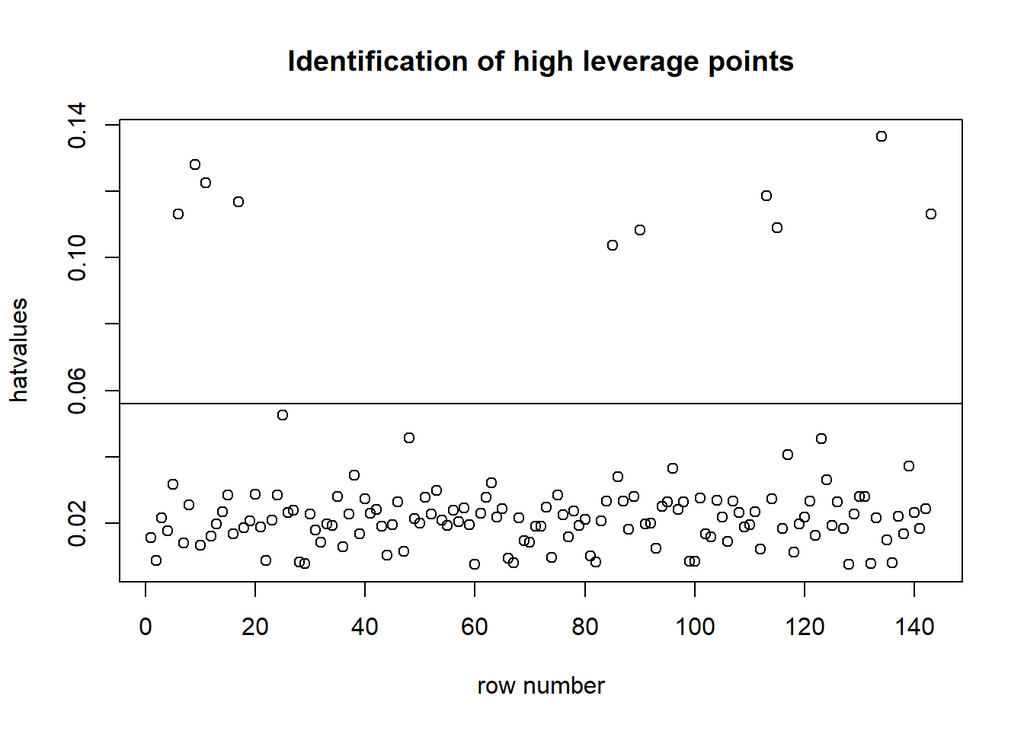

```r
row_num <- c(1:143)
plot(row_num, hat_value, xlab = "row number",
     ylab = "hatvalues",
     main = "Identification of high leverage points")
abline(h = (2*(k+1)/n))
```

```r
# Finding outliers using internally standardized residuals
r1 <- rstandard(mlr_step2)
which(abs(r1) > 3)
```

```
## named integer(0)
```